# Pre processing GSE125416

GSE125416 is an experiment comparing normal hESC cells and nicotine exposed hESC cells. High rate of cell cycle is expected. It contains two samples:

- GSM3573649 Control_EB scRNA-seq [D];
- GSM3573650 nicotine-exposed_EB scRNA-seq [N].

Data is accessible at [Gene Expression Omnibus - GSE125416](https://www.ncbi.nlm.nih.gov/geo/query/acc.cgi?acc=GSE125416).

Article is accessible at [Stem Cell Reports - Single-Cell RNA Sequencing of Human Embryonic Stem Cell Differentiation Delineates Adverse Effects of Nicotine on Embryonic Development](https://www.sciencedirect.com/science/article/pii/S2213671119300244)

# Read data

We use Seurat to read and preprocess the data.

```r
library(Seurat)
filepath1 = "/home/shaoheng/Documents/data/hESC-droplet/GSE125416/GSM3573649_D_filtered_gene_bc_matrices_h5.h5"
filepath2 = "/home/shaoheng/Documents/data/hESC-droplet/GSE125416/GSM3573650_N_filtered_gene_bc_matrices_h5.h5"
mat1 <- Read10X_h5(filepath1)
mat2 <- Read10X_h5(filepath2)
obj = CreateSeuratObject(cbind(mat1, mat2), project='both')
```

```
Non-unique cell names (colnames) present in the input matrix, making uniqueFeature names cannot have underscores ('_'), replacing with dashes ('-')
```

```r
obj$sample <- c(rep('normal', dim(mat1)[2]), rep('nicotine', dim(mat2)[2]))
obj
```

```
An object of class Seurat
33694 features across 12493 samples within 1 assay
Active assay: RNA (33694 features)
```

```r
rm(mat1)
rm(mat2)
gc()
```

```
            used   (Mb) gc trigger    (Mb)   max used    (Mb)
Ncells   2753316  147.1    4904490   262.0    4904490   262.0
Vcells 576894972 4401.4 1710027008 13046.5 1656804457 12640.5
```

# Filtering

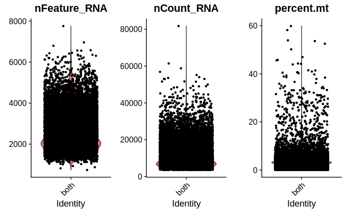

```r
obj[["percent.mt"]] <- PercentageFeatureSet(obj, pattern = "^MT-")
VlnPlot(obj, features = c("nFeature_RNA", "nCount_RNA", "percent.mt"), ncol = 3)
```

## Mitochondria and expressed genes

“cells with fewer than 200 or more than 6,000 expressed genes, and a high percentage of mitochondrial genes (>20%) were removed.” This is done by `subset`. Should keep 12280 cells.

```r
obj <- subset(obj, subset = nFeature_RNA > 200 & nFeature_RNA < 6000 & percent.mt < 20)
obj
```

```
An object of class Seurat
33694 features across 12280 samples within 1 assay
Active assay: RNA (33694 features)
```

## Normalization

“We next normalized the gene expression values for each cell by the total expression, multiplied by 10,000, and made a log-transformation.” This is done by `NormalizeData`.

```r
obj <- NormalizeData(obj)
```

## Variable genes

Variable expressed genes across the single cells under cutoff with an average expression of more than 0.0125 and less than 3, and dispersion of more than 0.5, were detected for down-stream analysis.

```r
obj <- FindVariableFeatures(obj, mean.cutoff = c(0.0125, 3), dispersion.cutoff = c(0.5, Inf))
```

## Cell cycle

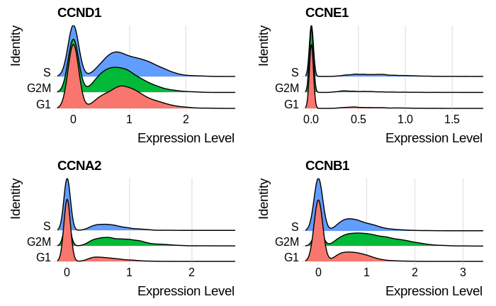

```r
obj <- CellCycleScoring(obj, s.features = cc.genes$s.genes, g2m.features = cc.genes$g2m.genes, set.ident = TRUE)
RidgePlot(obj, features = c("CCND1", "CCNE1", "CCNA2", "CCNB1"), ncol = 2)
```

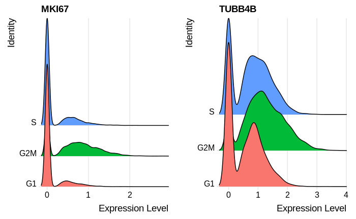

```r
RidgePlot(obj, features = c("MKI67", "TUBB4B"), ncol = 2)
```

## PCA

```r
obj <- ScaleData(obj, features = rownames(obj))
```

```r
obj <- RunPCA(obj, features = VariableFeatures(object = obj))
```

```
PC_ 1
Positive:  POU5F1, CLDN6, CD24, TERF1, RP11-568A7.4, RP11-148B6.1, PDLIM1, TDGF1, PLA2G16, SCGB3A2
       UTF1, RP11-1144P22.1, TMSB4X, L1TD1, FOXH1, UGP2, EPCAM, RARRES2, CLDN7, PODXL
       PTMA, DNMT3B, NMRK2, IFITM1, PFN1, FRAT2, CD9, EZR, PIM2, SLIRP
Negative:  DLK1, VIM, PRSS23, METRN, TMSB15A, COL2A1, ZNF436-AS1, SIX3, IGFBP5, PAX6
       NNAT, CRABP1, MEST, LHX2, SFRP2, MALAT1, EFNA5, TPBG, FABP7, SIX6
       RAX, SOX3, RBP1, HES1, PTN, RP11-89K21.1, FRZB, IGFBP2, ARL4C, TUBA1A
PC_ 2
Positive:  S100A11, ANXA2, CLDN4, ANXA1, KRT19, HAPLN1, KRT8, VGLL1, S100A16, NEAT1
       IGF2, WNT6, TACSTD2, GATA3, KRT18, TFAP2B, TFAP2A, LGALS3, ANXA3, SAT1
       S100A6, PRSS8, ELF3, SEMA3E, CYP1B1, TMEM40, S100A10, CXCL14, DSP, PERP
Negative:  CKS1B, CKS2, RANBP1, HMGB1, PTTG1, BIRC5, HMGB2, UBE2S, HSPE1, USP44
       UBE2C, FAM64A, CALM2, PTMA, RAN, HN1, EIF5A, ATP5G1, SNRPN, NUCKS1
       CENPF, TERF1, FABP5, CYCS, SLIRP, PRELID1, SET, DNMT3B, HIST1H4C, RP11-148B6.1
PC_ 3
Positive:  TUBA1B, HMGB1, TUBB4B, CENPF, HAPLN1, NUCKS1, HMGB2, PTTG1, HSP90AA1, NUSAP1
       MKI67, UBE2C, TOP2A, CENPW, CCNB1, ARL6IP1, BIRC5, TMSB10, AURKB, ACTB
       SMC4, DLX5, CDC20, HSP90B1, CKS1B, KPNA2, LHX5-AS1, CALM2, GNAS, CKS2
Negative:  RPL8, FTL, ZFAS1, RPSA, PLA2G16, RP11-1144P22.1, TDGF1, PMAIP1, NMRK2, DDIT3
       LINC00678, C9orf135, HSPB1, BBC3, UTF1, GDF15, IFITM3, NEAT1, POU5F1, CHCHD10
       FOXH1, PIM2, RP11-35J1.2, EPB41L4A-AS1, TAC1, RP11-568A7.4, MIAT, FOXD3-AS1, FXYD5, LINC01405
PC_ 4
Positive:  ENO1, UBC, GAPDH, EIF1, TUBA1A, PHGDH, ATP5B, TUBA1B, DDIT3, HSP90AB1
       TPI1, UCHL1, TAC1, KPNA2, GDF15, PSAT1, PGK1, ACTB, HSPA8, CALM2
       SARS, RAN, HSP90AA1, PSMA4, TUBB4B, HSPD1, DDIT4, CKB, PSMB1, CCNB1
Negative:  MT-CO3, MT-CO1, MT-ND4, MT-ND1, MT-CO2, MT-ND2, MT-ATP6, MT-CYB, MT-ND3, MT-ND5
       PODXL, JARID2, TMSB10, PTPRF, IRX2, PWAR6, TMSB4X, TRIM71, CDH1, LIN28A
       GJA1, FLNA, KCNK12, USP9X, INSR, SCD, DHCR24, PPP1R14B, PKDCC, TMEM54
PC_ 5
Positive:  ENO1, GAPDH, LHX5-AS1, LMO1, PGAM1, ACTB, HESX1, LHX5, PRDX1, CITED2
       TPI1, HAPLN1, PGK1, TMSB10, ABRACL, DLX5, HSP90AB1, MYL6, UQCRH, CRABP2
       GNAS, C1QBP, TNNT1, VSNL1, PSMB1, ACAT2, NDUFA4, PTMA, PSMB6, SHISA2
Negative:  TOP2A, UBE2C, CENPF, CENPA, MKI67, PIF1, TPX2, PLK1, PSRC1, UBE2S
       ASPM, CDKN3, HMGB2, AURKA, GTSE1, CDCA3, MALAT1, NUSAP1, ARL6IP1, CKS2
       CDK1, SGOL2, CENPE, CDC20, KPNA2, PRC1, AURKB, KNSTRN, SMC4, CCNB1
```

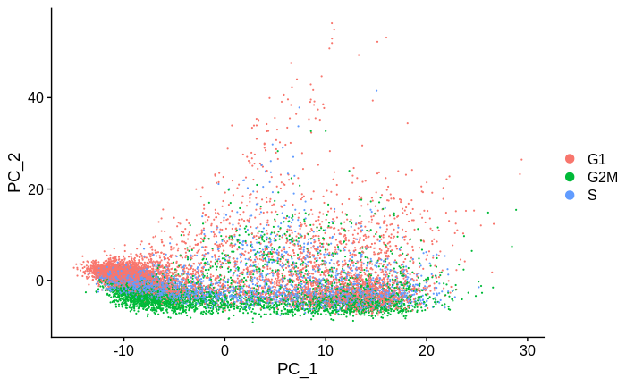

```r
DimPlot(obj)
```

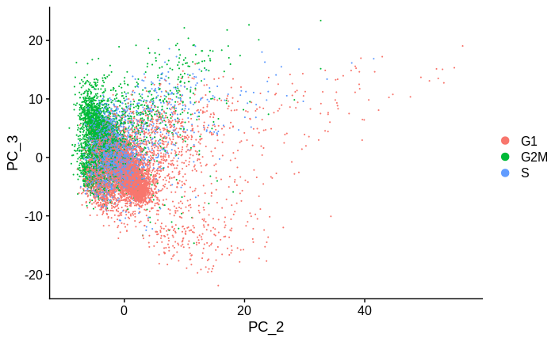

```r
DimPlot(obj, dims = c(2, 3), pt.size=0.1)
```

```r
saveRDS(obj, "~/Documents/data/hESC-droplet/GSE125416/GSM357650-regular.RDS")
```

```r
source("../utils/gsea.R")
mat2cls(as.matrix(obj@reductions$pca@cell.embeddings), "~/Documents/data/hESC-droplet/GSE125416/GSE125416-regular-pca.cls")
```

[output not shown]

[output cut: 35 more lines]

```r
source("../utils/hdfrw.R")
mat2hdf(as.matrix(obj@assays$RNA@scale.data), "~/Documents/data/hESC-droplet/GSE125416/GSE125416-regular.h5")
```